# (拍拍贷数据探索)

## by (Lulu Hwang)

## Investigation Overview

> 拍拍贷借款订单的逾期还款率主要分布情况，跟那些因素有相关性。逾期三期及以上的订单，主要分布表现。

## Dataset Overview

> 数据共有328553行，29列，分为三类：借款单信息，借款人信息，借款人历史借款信息。

> 借款单信息：'ListingId', '借款金额', '借款期限', '借款利率', '借款成功日期', '借款类型', '是否首标'，'逾期还款期数', '逾期三期及以上', '正常还款期数', '剩余本金', '剩余利息','逾期还款率' 借款人信息：'初始评级', '年龄', '性别', '手机认证', '户口认证', '视频认证', '学历认证', '征信认证', '淘宝认证', '认证数' 借款人历史借款信息：'历史成功借款次数', '历史成功借款金额', '总待还本金', '历史正常还款期数', '历史逾期还款期数', '历史逾期还款率'

## (Visualization 1)

> 借款金额主要集中在2000-10000元区间，也有少量其他值较大的，最大达到500000，但是总体分布呈双峰分布，分别是800-1000，2000-6000两个区间,后者集中数量最多。

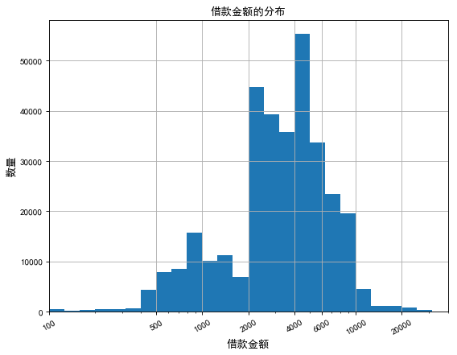

```python
plt.figure(figsize=(8,6), dpi= 80);
bins=10**np.arange(2,4.5+0.1,0.1)
ticks=[100,500,1000,2000,4000,6000,10000,20000,50000]
labels=['{}'.format(v) for v in ticks]
plt.hist(data=LC1,x="借款金额",bins=bins);
plt.xscale('log');
plt.xticks(rotation=30);
plt.xticks(ticks,labels);
plt.grid(True);
plt.xlabel('借款金额',fontsize= 'large');
plt.ylabel('数量',fontsize = 'large') ;
plt.xlim(100,40000)
plt.title('借款金额的分布');
```

## (Visualization 2)

> 初始评级主要集中在C、D两个级别上。中部分布比较集中。

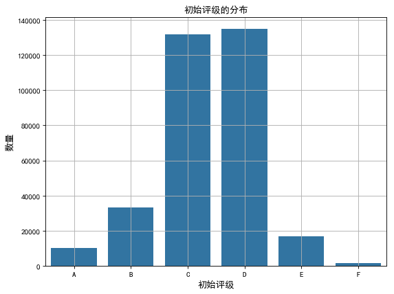

```python
plt.figure(figsize=(8,6), dpi= 80)
default_color = sb.color_palette()[0]
sb.countplot(data = LC1, x =LC1["初始评级"], color = default_color);
plt.grid(True);
plt.xlabel('初始评级',fontsize= 'large');
plt.ylabel('数量',fontsize = 'large') ;
plt.title('初始评级的分布') ;
plt.show();
```

## (Visualization 3)

> 初始评级越高，逾期还款率越低。

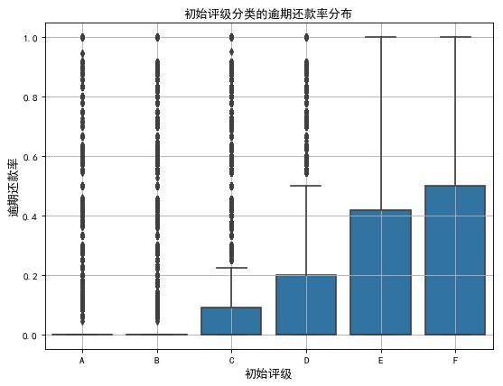

```python
plt.figure(figsize=(8,6), dpi= 80);
sb.boxplot(data=LC1,x="初始评级",y="逾期还款率",color=basic_color);
plt.grid(True);
plt.xlabel('初始评级',fontsize= 'large');
plt.ylabel('逾期还款率',fontsize = 'large') ;
plt.title('初始评级分类的逾期还款率分布') ;
```

## 所以初始评级低的话，风险就高，是不是借款利率要高呢？

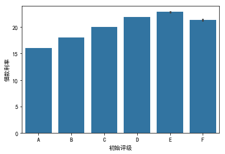

```python
sb.barplot(x="初始评级",y="借款利率",data=LC1,color=basic_color)
```

## (Visualization 5)

> 首标的各信用等级平均逾期还款率比非首标的要高，表明，首标用户的信用违约率需要更加强管控。

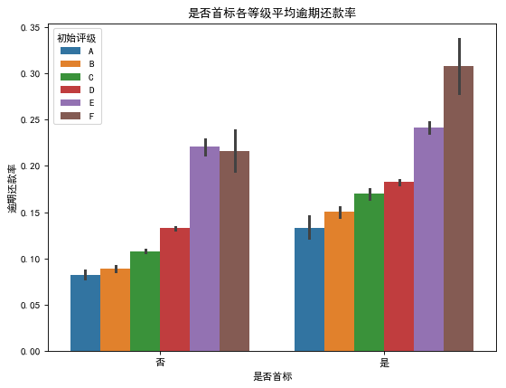

```python
plt.figure(figsize=(8,6), dpi= 80);
sb.barplot(x="是否首标",y="逾期还款率",hue="初始评级",data=LC1);
plt.title('是否首标各等级平均逾期还款率') ;
```

## (Visualization 6)

> 整体的逾期还款率(尤其是D\E\F几个评级)都随着年龄的增大而有降低的趋势。年龄组内，进一步确认了，信用评级跟逾期还款率的关系，评级越低，逾期风险越大。 有趣的发现，46-56的客户虽然我们认为还款能力在降低，但是违约率并没有升高。对于这个群体的放款审核模式可以继续保留。

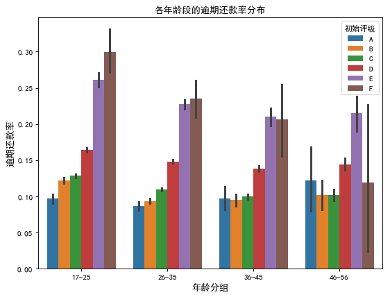

```python
plt.figure(figsize=(8,6), dpi= 80);
sb.barplot(x="年龄",y="逾期还款率",hue="初始评级",data=LC1);
plt.xlabel('年龄分组',fontsize= 'large');
plt.ylabel('逾期还款率',fontsize = 'large') ;
plt.title('各年龄段的逾期还款率分布');
```

## (Visualization 7)

> 通过以下散点图的拟合线性回归可以大概了解到，历史正常还款期数与历史成功借款次数有正相关性，表明拍拍贷在审核贷款的时候，正常还款情况越好可以再次借到新的款项的可能性越大。

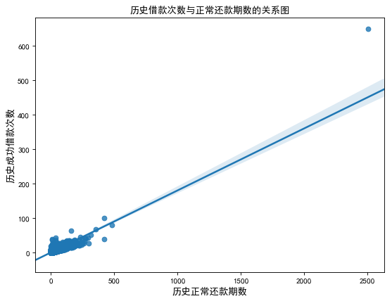

```python
plt.figure(figsize=(8,6), dpi= 80);
sb.regplot(LC1["历史正常还款期数"],LC1["历史成功借款次数"]);
plt.xlabel('历史正常还款期数',fontsize= 'large');
plt.ylabel('历史成功借款次数',fontsize = 'large');
plt.title('历史借款次数与正常还款期数的关系图');
```

## (Visualization 8)

> 让我们看看逾期还款率和历史逾期还款率的累计百分比。

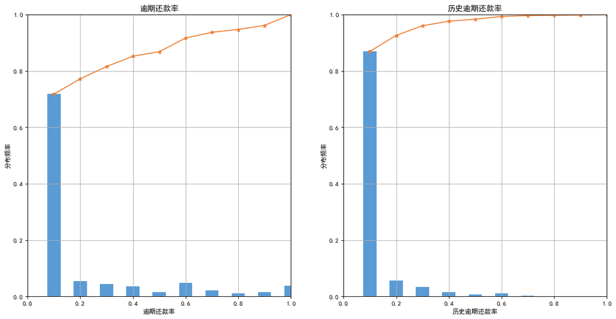

```python
from scipy import stats
plt.figure(figsize=(16,8), dpi= 80)
plt.subplot(1,2,1)
LC_NOTNULL=LC1.loc[~(LC1["逾期还款率"].isnull())]
hist,bin_edges= np.histogram(LC_NOTNULL["逾期还款率"])
width=(bin_edges[1] - bin_edges[0]) * 0.5
pdf=hist/sum(hist)
plt.bar(bin_edges[1:], pdf,width=width,color='#5B9BD5');
cdf=np.cumsum(pdf)
plt.plot(bin_edges[1:], cdf, '-*', color='#ED7D31');
plt.xlim([0, 1])
plt.ylim([0, 1])
plt.grid()
plt.title("逾期还款率")
plt.xlabel("逾期还款率")
plt.ylabel("分布频率")


plt.subplot(1,2,2)
LC_NOTNULL=LC1.loc[~(LC1["历史逾期还款率"].isnull())]
hist,bin_edges= np.histogram(LC_NOTNULL["历史逾期还款率"])
width=(bin_edges[1] - bin_edges[0]) * 0.5
pdf=hist/sum(hist)
plt.bar(bin_edges[1:],pdf,width=width,color='#5B9BD5');
cdf=np.cumsum(pdf)
plt.plot(bin_edges[1:],cdf, '-*', color='#ED7D31');
plt.xlim([0, 1])
plt.ylim([0, 1])
plt.grid()
plt.title("历史逾期还款率")
plt.xlabel("历史逾期还款率")
plt.ylabel("分布频率")
plt.legend()
plt.show();
```

> 不是首标的用户，历史逾期还款率85%在10%内，探索订单的逾期总体还款率（包含首标和非首标）约70%在10%以内，可以看到历史逾期还款率的数据更加往左集中。可以猜测到拍拍贷在发放贷款时对非首标客户已经经过筛选。

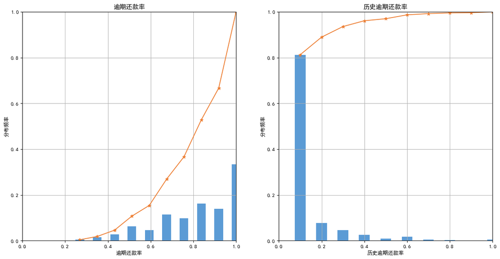

```python
plt.figure(figsize=(16,8), dpi= 80)
plt.subplot(1,2,1)
hist,bin_edges= np.histogram(LC3["逾期还款率"])
width=(bin_edges[1] - bin_edges[0]) * 0.5
pdf=hist/sum(hist)
plt.bar(bin_edges[1:], pdf,width=width,color='#5B9BD5');
cdf=np.cumsum(pdf)
plt.plot(bin_edges[1:], cdf, '-*', color='#ED7D31');
plt.xlim([0, 1])
plt.ylim([0, 1])
plt.grid()
plt.title("逾期还款率")
plt.xlabel("逾期还款率")
plt.ylabel("分布频率")


plt.subplot(1,2,2)
LC_NOTNULL=LC3.loc[~(LC3["历史逾期还款率"].isnull())]
hist,bin_edges= np.histogram(LC_NOTNULL["历史逾期还款率"])
width=(bin_edges[1] - bin_edges[0]) * 0.5
pdf=hist/sum(hist)
plt.bar(bin_edges[1:],pdf,width=width,color='#5B9BD5');
cdf=np.cumsum(pdf)
plt.plot(bin_edges[1:],cdf, '-*', color='#ED7D31');
plt.xlim([0, 1])
plt.ylim([0, 1])
plt.grid()
plt.title("历史逾期还款率")
plt.xlabel("历史逾期还款率")
plt.ylabel("分布频率")
plt.legend()
plt.show();
```

> 严重逾期的本期逾期还款率分布明显偏右，但是历史数据表现又很不错，说明通过历史数据并不能很好的控制违约风险。

## (Visualization 9)

[figure not shown]

```python
default_color = sb.color_palette()[0]
plt.subplot(3,2,1)
sb.countplot(data = LC1, x ='借款期限', color = default_color)
plt.subplot(3,2,2)
sb.countplot(data = LC1, x ='初始评级', color = default_color)
plt.subplot(3,2,3)
sb.countplot(data = LC1, x ='是否首标', color = default_color)
plt.subplot(3,2,4)
sb.countplot(data = LC1, x ='年龄', color = default_color)
plt.subplot(3,2,5)
sb.countplot(data = LC1, x ='性别', color = default_color)
plt.subplot(3,2,6)
sb.countplot(data = LC1, x ='认证数', color = default_color)
plt.subplots_adjust(wspace=1, hspace=1)
plt.title("严重逾期订单分类指标分布",x=-0.3,y=5.3)
plt.show();
```

> 但是这些特征就一定是严重违约的预兆吗？

> 不是的，我们发现总体的分布也是如此。

[figure not shown]

```python
default_color = sb.color_palette()[0]
plt.subplot(3,2,1)
sb.countplot(data = LC3, x ='借款期限', color = default_color)
plt.subplot(3,2,2)
sb.countplot(data = LC3, x ='初始评级', color = default_color)
plt.subplot(3,2,3)
sb.countplot(data = LC3, x ='是否首标', color = default_color)
plt.subplot(3,2,4)
sb.countplot(data = LC3, x ='年龄', color = default_color)
plt.subplot(3,2,5)
sb.countplot(data = LC3, x ='性别', color = default_color)
plt.subplot(3,2,6)
sb.countplot(data = LC3, x ='认证数', color = default_color)
plt.subplots_adjust(wspace=1, hspace=1)
plt.title("总体分类指标分布",x=-0.3,y=5.3)
plt.show();
```

## (Visualization 10)

> 我们探索下，初始评级下，历史成功借款次数与逾期还款率的关系

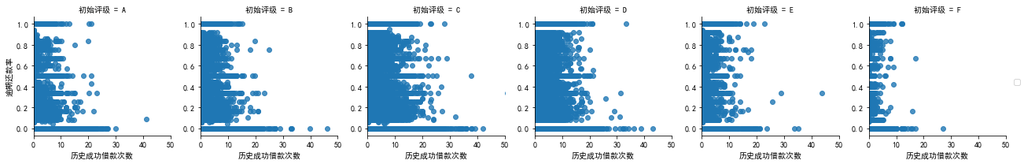

```python
g = sb.FacetGrid(LC1, col="初始评级", sharex=True, sharey=True,xlim=(0,50))
g.map(sb.regplot, "历史成功借款次数", "逾期还款率",
      fit_reg=False, x_jitter=.2)
g.add_legend();
```

> 没有特别的相关性，但是可以看到，随着成功借款次数地增加，逾期还款率会往低处分布。各等级在借款次数30次以上的违约率大幅降低，风险相对可控。